# Emma – sur la voie du professorat ?

28.06.2021

**L’exemple d’Emma* nous permet d’illustrer le parcours professionnel d’une jeune chercheuse dont le doctorat a été financé par l’intermédiaire d’un projet du FNS. À cette fin, nous avons rapproché et analysé des données de l’Office fédéral de la statistique (OFS) et du FNS. *Emma est un pseudonyme.**

Sur mandat de la Confédération, le FNS encourage la recherche scientifique dans toutes les disciplines à travers différentes mesures. L’un de ses principaux objectifs est d’améliorer les perspectives de carrière de la relève scientifique. Le FNS investit ainsi un peu plus du quart de ses ressources dans l’encouragement de carrières, instrument qui s’adresse aux jeunes chercheuses et chercheurs prometteurs. Nombre d’entre eux collaborent par ailleurs à d’autres projets financés par le FNS. En 2018, 23 % des assistant·es, collaboratrices et collaborateurs de recherche travaillant au sein des universités suisses (soit un total de 22’503 équivalents temps plein) étaient soutenus par le FNS.

L’exemple d’Emma est l’illustration d’un parcours professionnel possible[^1], du début du doctorat jusqu’à cinq ans après l’obtention de celui-ci. En 2013 et 2017, Emma a participé à deux enquêtes réalisées par l’OFS auprès des diplômé·es des hautes écoles. Nous l’avons sélectionnée car son parcours professionnel constitue un exemple très parlant. Afin de préserver son anonymat, des détails ont été légèrement modifiés ou délibérément omis.

### Phase de doctorat avec séjour à l’étranger

Après avoir passé son master dans une discipline MINT (mathématiques, informatique, sciences naturelles et technique), Emma a obtenu un poste de doctorante en 2009. Comme 32 % des doctorant·es en Suisse, elle a poursuivi au moins une partie de son doctorat dans le cadre d’un projet encouragé par le FNS.

Encouragement par le FNS : quelle est la part financée sur la durée du doctorat ?

[interactive chart not shown]

Diplômé·es avec encouragement du FNS uniquement. Données recueillies par l’OFS auprès des diplômé·es des « hautes écoles », enquêtes initiales de 2013, 2015 et 2017.

Le graphique ci-dessus montre que les diplômé·es ont bénéficié durant différentes périodes de leur doctorat de l’encouragement du FNS. Dans la plupart des cas, cette durée représentait plus de 50 % de leur doctorat.

Emma a investi beaucoup de temps dans son doctorat. Elle consacrait en effet près de 50 heures par semaine à son projet, soit environ 13 heures de plus que la moyenne des doctorant·es.

Au bout d’un certain temps, une possibilité de collaboration avec un autre groupe de recherche est apparue. Emma a saisi cette opportunité et effectué un séjour de recherche à l’étranger, où elle a élaboré une partie de sa thèse. Comme Emma, 21 % des doctorant·es effectuent un séjour de recherche ou d’étude à l’étranger. 3 % se rendent dans une autre institution en Suisse et 2 % optent pour un séjour à l’étranger et un en Suisse.

Séjours de recherche ou d’études durant le doctorat

[interactive chart not shown]

Réponses vides supprimées. Données recueillies par l’OFS auprès de diplômé·es des « hautes écoles », enquêtes initiales de 2013, 2015 et 2017.

### Doctorat obtenu en un temps record

À l’inverse, 16 % des personnes soutenues par le FNS interrompent leurs études de doctorat (contre 26 % de celles ne bénéficiant pas d’un financement du FNS). Raisons les plus fréquemment invoquées lors d’un arrêt en cours de parcours : la charge de travail trop importante induite par des activités extérieures à la recherche et les obligations familiales.

Selon les [données recueillies par l’OFS](https://www.bfs.admin.ch/bfs/fr/home/statistiques/education-science/transitions-parcours-domaine-formation/degre-tertiaire.html), 21 % des doctorant·es abandonnent leurs études de doctorat sans obtenir de diplôme dix ans après les avoir débutées. Ces personnes n’ont par conséquent pas été interrogées dans le cadre des enquêtes réalisées.

Durée du doctorat

[interactive chart not shown]

Emma 3,4 a. / 100 % = il a fallu à Emma 3,4 ans pour mener à bien son doctorat et elle était financée à 100 % par le FNS. Échantillon aléatoire de 1’000 réponses. Réponses vides et réponses avec une durée de doctorat supérieure à 12 ans supprimées. Données recueillies par l’OFS auprès des diplômé·es des « hautes écoles », enquêtes initiales de 2013, 2015 et 2017.

Comme 26 % de celles et ceux qui ont obtenu leur doctorat l’an dernier, Emma aspire à une carrière académique. Les personnes ayant directement bénéficié d’une mesure d’encouragement de carrières du FNS durant leur doctorat expriment beaucoup plus souvent ce vœu professionnel (51 %) que celles qui ont obtenu un financement de par leur participation à un projet du FNS (26 %) ou via une autre source (24 %).

### La plupart abandonnent la recherche au bout d’un an

Un an après l’obtention de son doctorat, Emma est toujours engagée à 100 % au sein d’une haute école où elle exerce une activité scientifique. Globalement, ceci vaut pour 35 % des personnes interrogées, sachant que 50 % ont quitté le milieu académique, que 10 % sont sans emploi et que des informations plus précises font défaut pour 4 % d’entre elles. Près de la moitié des personnes dont le doctorat a été soutenu par le FNS (45 %) continuent de se consacrer à la science un an après la fin de leur doctorat contre seulement 31 % de celles dont les études ont été financées différemment.

Un an après avoir achevé leur doctorat, la plupart des diplômé·es ne travaillent déjà plus dans le domaine académique. Néanmoins, 57 % d’entre eux poursuivent une carrière dans le secteur public, 8 % exercent une activité dans une organisation à but non lucratif et 35 % ont rejoint le secteur privé.

Avant de décrocher leur premier poste après le doctorat, les personnes interrogées ont en moyenne déposé 21 candidatures. Ce chiffre est cependant fortement influencé par le grand nombre de démarches de candidature effectuées par certains. La moitié des diplômé·es ont toutefois envoyé moins de 5 postulations.

### Cinq ans après – bilan intermédiaire

Transitions entre le secteur académique et non académique

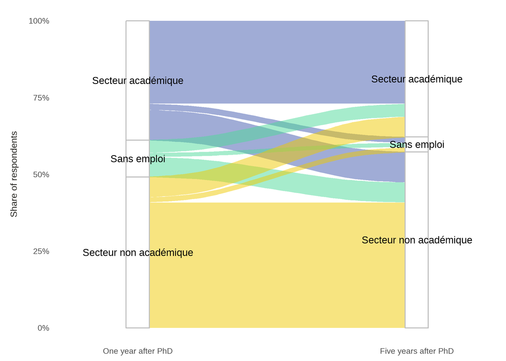

Enquête « Hautes écoles » de l’OFS. Pour une meilleure lisibilité, seuls sont pris en compte les diplômé·es ayant participé à une enquête initiale en 2013 et à une seconde en 2017 et dont le secteur d’activité pouvait être déterminé.

Parmi ceux ayant quitté le milieu universitaire, la plupart ne disposent pas du statut de cadre (32 %), ou occupent des positions de cadres inférieurs (30 %).

Cinq ans après l’obtention de son diplôme, Emma a le sentiment qu’elle n’a toujours pas atteint ses objectifs professionnels. Et elle n’est pas la seule : 19 % de ses collègues sont du même avis, même si 23 % d’entre eux estiment les avoir entièrement atteints.

La situation d’Emma a également évolué dans le domaine privé au cours de ces cinq années : elle est entre-temps devenue mère. Elle se retrouve donc en bonne compagnie, car si 23 % des diplômé·es ont des enfants peu après avoir passé leur doctorat, ils sont 44 % à avoir fondé une famille cinq ans plus tard.

### Données et méthodes

Afin de mieux connaître la situation des doctorant·es soutenus, le FNS a regroupé et analysé les données de l’enquête réalisée auprès des diplômé·es des « hautes écoles » par l’Office fédéral de la statistique (OFS) avec les informations dont il disposait. Cela a permis d’établir une distinction entre les personnes qui avaient été encouragées par le FNS et celles qui avaient bénéficié d’un autre financement.

Dans le cadre de l’enquête qu’il mène tous les deux ans, l’OFS interroge les diplômé·es des hautes écoles sur leur situation en matière d’emploi et de formation un an et cinq ans après l’obtention de leur doctorat. Les données des enquêtes initiales de 2013, 2015 et 2017 et de la deuxième enquête de 2017 ont été utilisées pour l’analyse.

### Pour aller plus loin

- [Enquête auprès des personnes diplômées des hautes écoles, Office fédéral de la statistique](https://www.bfs.admin.ch/bfs/fr/home/statistiques/education-science/enquetes/ashs.html)
- [Instruments d’encouragement de carrières du FNS](http://www.snf.ch/fr/encouragement/carrieres/Pages/default.aspx)
- [Étude en cours du FNS sur l’évolution de la carrière des jeunes chercheuses et chercheurs](https://careertrackercohorts.ch/)

Le texte et des parties du code de ce récit de données sont [disponibles sur Github](https://github.com/snsf-data/datastory_graduate_careers) et [archivés sur Zenodo](https://doi.org/10.46446/datastory.emma-on-her-way-to-a-professorship). En raison de dispositions contractuelles, les données utilisées et certaines parties du code ne peuvent être publiées. DOI: 10.46446/datastory.emma-on-her-way-to-a-professorship

[^1]: Dans une version précédente de ce récit de données, le parcours professionnel d’Emma était qualifié de *typique*. Suite à plusieurs réactions, nous avons procédé à une adaptation, car l’exemple d’Emma n’est pas représentatif de la majorité des doctorant·es en Suisse.